# 成為初級資料分析師 | Python 機器學習

> 迴歸

## 郭耀仁

## 大綱

- NBA 球員的年薪
- 線性迴歸模型
- 非線性迴歸模型
- 加入類別變數的迴歸模型
- 誤差的來源

## NBA 球員的年薪

## 資料來源

- [Hoopshype](https://hoopshype.com/salaries/players/)
- [data.nba.net](http://data.nba.net/10s/prod/v1/today.json)

```python
import numpy as np
import pandas as pd

nba_players = pd.read_csv("https://kaggle-getting-started.s3-ap-northeast-1.amazonaws.com/regression/nba_players.csv")
print(nba_players.shape)
nba_players.head()
```

```
(229, 38)
```

|  | personId | personName | apg | assists | blocks | bpg | dateOfBirthUTC | dd2 | defReb | fga | ... | steals | td3 | teamId | totReb | tpa | tpm | tpp | turnovers | weightKilograms | salary |
| --- | --- | --- | --- | --- | --- | --- | --- | --- | --- | --- | --- | --- | --- | --- | --- | --- | --- | --- | --- | --- | --- |
| 0 | 201939 | Stephen Curry | 6.6 | 4588 | 154 | 0.2 | 1988-03-14 | 118 | 2646 | 11849 | ... | 1200 | 7 | 1610612744 | 3132 | 5690 | 2483 | 43.6 | 2163 | 86.2 | 40231758 |
| 1 | 101108 | Chris Paul | 9.7 | 9181 | 122 | 0.1 | 1985-05-06 | 436 | 3621 | 13132 | ... | 2122 | 15 | 1610612745 | 4262 | 3426 | 1268 | 37.0 | 2304 | 79.4 | 38506482 |
| 2 | 202322 | John Wall | 9.2 | 5282 | 396 | 0.7 | 1990-09-06 | 253 | 2153 | 9107 | ... | 976 | 7 | 1610612764 | 2483 | 1663 | 539 | 32.4 | 2191 | 95.3 | 38199000 |
| 3 | 201935 | James Harden | 6.2 | 4743 | 383 | 0.5 | 1989-08-26 | 196 | 3418 | 12411 | ... | 1189 | 42 | 1610612745 | 4000 | 5551 | 2025 | 36.5 | 2770 | 99.8 | 38199000 |
| 4 | 201566 | Russell Westbrook | 8.4 | 6897 | 250 | 0.3 | 1988-11-12 | 369 | 4389 | 15253 | ... | 1442 | 138 | 1610612760 | 5760 | 2995 | 922 | 30.8 | 3326 | 90.7 | 38150000 |

5 rows × 38 columns

## 年薪的直方圖（Histogram plot）

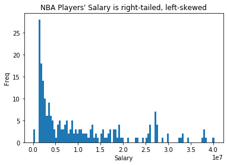

```python
get_salary_hist()
```

## 場均得分與年薪的散佈圖（Scatter plot）

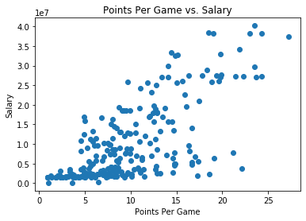

```python
get_scatter_plot()
```

## 線性迴歸模型

## 線性迴歸模型的 E, T, 與 P

> A computer program is said to learn from experience E with respect to some class of tasks T and performance measure P if its performance at tasks in T, as measured by P, improves with experience E.

> Tom Mitchel

## E: Experience

NBA 球員的場均得分與年薪資料

```python
from sklearn.model_selection import train_test_split

X = nba_players["ppg"].values.reshape(-1, 1)
y = nba_players["salary"].values
X_train, X_validation, y_train, y_validation = train_test_split(X, y, test_size=0.33, random_state=42)
```

## T: Task

與球員（Rookies or Free Agents）簽約時時能夠依據其場均得分給予年薪（可以為絕大多數球員與經紀人接受）

```python
import numpy as np

X_test = np.array([10]).reshape(-1, 1) # 一位場均得分 10 的球員
X_test = np.array([15]).reshape(-1, 1) # 一位場均得分 15 的球員
```

## P: Performance

- 跟 $f$ 長得很像的 $h$，合約被多數球員與經紀人**接受**
- 跟 $f$ 長得不太像的 $h$，合約被多數球員與經紀人**婉拒**

## 線性迴歸模型 in short

建立一個輸入向量 $x$ 能夠得到純量 $\hat{y}$ 輸入的系統 $h$，$x$ 與 $\hat{y}$ 符合線性關係，其中向量 $w$ 稱為是系統的參數

$$\hat{y} = h(x) = w_0 + w_1 x_1 + w_2 x_2 + ... + w_n x_n \\ \hat{y} = h(x) = w_0 x_0 + w_1 x_1 + w_2 x_2 + ... + w_n x_n \text{ , where } x_0 = 1 \\ \hat{y} = h(x) = w^Tx$$

## 將 $h$ 表示得更廣泛

$$\hat{y} = h(X) = \begin{bmatrix} x_{00}, x_{01}, ..., x_{0n} \\ x_{10}, x_{11}, ..., x_{1n} \\.\\.\\.\\ x_{m0}, x_{m1}, ..., x_{mn} \end{bmatrix} \begin{bmatrix} w_0 \\ w_1 \\.\\.\\.\\ w_n \end{bmatrix} = Xw$$

## $w$：系統的參數

- $w_i$ 為正，表示 $x_i$ 這個特徵對 $\hat{y}$ 的影響為正向
- $w_i$ 為負，表示 $x_i$ 這個特徵對 $\hat{y}$ 的影響為負向
- $w_i$ 為零，表示 $x_i$ 這個特徵對 $\hat{y}$ 沒有影響

## 使用 MSE（Mean Squared Error）評估 $h$ 跟 $f$ 的相似程度

$$MSE_{test} = \frac{1}{m}\sum_i(\hat{y}^{(test)} - y^{(test)})_i^2$$

## 球季結束，將所有已經完成簽約自由球員（Free agents）跟新人（Rookies）的場均得分輸入 $h$，獲得年薪 $\hat{y}^{(test)}$，跟實際簽約金額 $y^{(test)}$ 比較

## 當預測年薪 $\hat{y}^{(test)}$，跟實際簽約金額 $y^{(test)}$ 相同，$MSE_{test}$ 為零

## 使用 Scikit-Learn API 尋找 $w$

```python
from sklearn.linear_model import LinearRegression

lr = LinearRegression()
lr.fit(X_train, y_train)
print(lr.intercept_) # w_0
print(lr.coef_) # w_1
```

```
-2320443.4754383415
[1290102.08619043]
```

## 使用 $w$ 作預測

```python
y_hat = lr.predict(X_validation)
print(y_hat)
```

```
[ 1420852.57451389  5291158.83308517 17160098.02603709  4388087.37275187
 20643373.65875124  1549862.78313294 17805149.06913231  8645424.25718028
  4001056.74689475 16773067.40017996  -514300.55477175 25287741.16903677
 14321873.43641816  5291158.83308517  2452934.24346623  3872046.5382757
 12386720.30713252 12902761.14160869  5033138.41584709  9419485.50889453
 13547812.1847039  14321873.43641816 10709587.59508496  3872046.5382757
 19224261.36394177 26448833.04660816 14063853.01918007  9935526.34337071
 10451567.17784688  6839281.33651368 12515730.51575156 11225628.42956113
 10580577.38646592  9935526.34337071 18708220.5294656  16902077.60879901
 16515046.98294188  8645424.25718028  7355322.17098985 11741669.2640373
 10580577.38646592 10064536.55198975  3614026.12103762  9677505.92613262
 12128699.88989443 19611291.9897989   6710271.12789464  4130066.95551379
  7613342.58822794 11225628.42956113  4904128.20722804 11354638.63818017
  8774434.46579932  3614026.12103762  7742352.79684698  8387403.83994219
  9677505.92613262 12128699.88989443  8903444.67441836 14966924.47951337
  9161465.09165645 19998322.61565603  3743036.32965666 16902077.60879901
  6581260.9192756  17031087.81741805  6323240.50203751  9032454.88303741
  8000373.21408507 32770333.26894125 13805832.60194198  9032454.88303741
  7355322.17098985   388770.90556155 14708904.06227528  2065903.61760911]
```

## 以 MSE 評估 $h$ 與 $f$ 的相似程度

```python
from sklearn.metrics import mean_squared_error

mse = mean_squared_error(y_validation, y_hat)
print(mse)
```

```
51938574189528.625
```

## `lr.fit(X_train, y_train)` 發生了什麼神奇的事情？

## 要看一下公式

$$ \bigtriangledown_w MSE_{train} = 0 \\ \bigtriangledown_w \frac{1}{m}\sum_i(\hat{y}^{(train)} - y^{(train)})_i^2 = 0\\ $$

## 看公式之前複習幾個向量、矩陣相乘的特性

- $x$ 與 $y$ 兩個維度相同的向量相乘為 $x^Ty$、亦等於 $y^Tx$
- $A$ 與 $B$ 矩陣相乘後的轉置運算為 $(AB)^T = B^TA^T$
- $Ax = b$ 的解為 $x = A^{-1}b$

## $x$ 與 $y$ 兩個維度相同的向量相乘為 $x^Ty$、亦等於 $y^Tx$

```python
import numpy as np

x = np.array([1, 2, 3]).reshape(-1, 1)
y = np.array([4, 5, 6]).reshape(-1, 1)
print(x.T.dot(y))
print(y.T.dot(x))
```

[output not shown]

## $A$ 與 $B$ 矩陣相乘後的轉置運算為 $(AB)^T = B^TA^T$

```python
import numpy as np

A = np.arange(1, 7).reshape(2, 3)
B = np.arange(1, 7).reshape(3, 2)
print((A.dot(B)).T)
print(B.T.dot(A.T))
```

```
[[22 49]
 [28 64]]
[[22 49]
 [28 64]]
```

## $Ax = b$ 的解為 $x = A^{-1}b$

$$ \begin{cases} x_1 + 2x_2 = 5 \\ 3x_1 + 4x_2 = 6 \end{cases} \\ \begin{bmatrix} 1 & 2 \\ 3 & 4 \end{bmatrix} \begin{bmatrix} x_1 \\ x_2 \end{bmatrix} = \begin{bmatrix} 5 \\ 6 \end{bmatrix} \\ $$

```python
# import numpy as np

A = np.array([1, 2, 3, 4]).reshape(2, 2)
b = np.array([5, 6]).reshape(2, 1)
A_inv = np.linalg.inv(A)
x = A_inv.dot(b)
print(A.dot(x))
print(x)
```

```
[[5.]
 [6.]]
[[-4. ]
 [ 4.5]]
```

## 機器學習的任務：找出一組向量 $w$ 讓訓練資料的 $MSE_{train}$ 最小

$$\bigtriangledown_w MSE_{train} = 0 \\ \bigtriangledown_w \frac{1}{m}\sum_i(\hat{y}^{(train)} - y^{(train)})_i^2 = 0\\ \frac{1}{m} \bigtriangledown_w (\hat{y}^{(train)} - y^{(train)})^T(\hat{y}^{(train)} - y^{(train)}) = 0\\ \bigtriangledown_w (X^{(train)}w - y^{(train)})^T(X^{(train)}w - y^{(train)}) = 0 \\ \frac{\partial}{\partial w} (w^TX^{(train)T}X^{(train)}w - 2w^TX^{(train)T}y^{(train)} + y^{(train)T}y^{(train)}) = 0 \\ 2X^{(train)T}X^{(train)}w - 2X^{(train)T}y^{(train)} = 0 \\ w = (X^{(train)T}X^{(train)})^{-1}X^{(train)T}y^{(train)} $$

## 這個求解稱為 normal equations，又稱 closed form solution

$$w = (X^{(train)T}X^{(train)})^{-1}X^{(train)T}y^{(train)}$$

## 給定 $X_{train}$ 與 $y_{train}$ 利用 normal equations 求 $w$

```python
nba_players = pd.read_csv("https://kaggle-getting-started.s3-ap-northeast-1.amazonaws.com/regression/nba_players.csv")
X = nba_players["ppg"].values.reshape(-1, 1)
X_0 = np.ones(X.shape[0]).reshape(-1, 1)
X = np.concatenate([X_0, X], axis=1)
y = nba_players["salary"].values.reshape(-1, 1)
X_train, X_validation, y_train, y_validation = train_test_split(X, y, test_size=0.33, random_state=42)
```

```python
def get_w_ne(X_train, y_train):
    X_train_T = X_train.T
    X_train_T_X_train = X_train_T.dot(X_train)
    X_train_T_X_train_inverse = np.linalg.inv(X_train_T_X_train)
    w = X_train_T_X_train_inverse.dot(X_train_T.dot(y_train))
    return w
```

```python
w = get_w_ne(X_train, y_train)
print(w)
```

```
[[-2320443.47543833]
 [ 1290102.08619043]]
```

## 給定 $w$、$X_{validation}$ 計算 $MSE_{validation}$

```python
y_hat = X_validation.dot(w)
n_validation_data = X_validation.shape[0]
mse_validation = ((y_hat - y_validation)**2).sum() / n_validation_data
print(mse_validation)
```

```
51938574189528.625
```

```python
print(w)
```

```
[[-2320443.47543834]
 [ 1290102.08619043]]
```

## 將 $h$ 在訓練資料上描繪出來

```python
nba_players = pd.read_csv("https://kaggle-getting-started.s3-ap-northeast-1.amazonaws.com/regression/nba_players.csv")
X = nba_players["ppg"].values.reshape(-1, 1)
y = nba_players["salary"].values
X_train, X_validation, y_train, y_validation = train_test_split(X, y, test_size=0.33, random_state=42)
```

```python
def get_h_plot(w):
    X_pred = np.linspace(X_train.min(), X_train.max(), 100)
    X_0 = np.ones(X_pred.size).reshape(-1, 1)
    X_pred_X_0 = np.concatenate([X_0, X_pred.reshape(-1, 1)], axis=1)
    y_pred = X_pred_X_0.dot(w)
    fig = plt.figure()
    ax = plt.axes()
    ax.scatter(X_train, y_train, label="train", s=5)
    ax.plot(X_pred, y_pred, label="h", c="red", linewidth=2)
    ax.legend()
    plt.show()
```

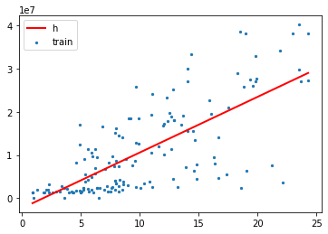

```python
get_h_plot(w)
```

## 非線性迴歸模型

## 回憶機器學習的任務：於可及範圍的 $H$ 中挑選一個與 $f$ 最相似的 $h_i$

$$y = f(x)$$$$\boldsymbol{H} = \{h_1,h_2,\dotsc,h_n\}$$$$\hat{y} = h_i(x)$$

## 如何擴增迴歸模型的可及範圍 $H$？

- 加入更多的特徵（features）
  - **高次項（polynomials）**
  - 其他變數
  - 其他衍生變數...etc.

## 加入二次項

$$\hat{y} = h(x) = w_0 + w_1 x_1 + w_2 x_1^2 \\ \hat{y} = h(x) = w_0 + w_1 x_1 + w_2 x_1^2 \text{ , where } x_0 = 1 \\ \hat{y} = h(x) = w^Tx$$

## 給定 $X$ 新增二次項

```python
import pandas as pd

nba_players = pd.read_csv("https://kaggle-getting-started.s3-ap-northeast-1.amazonaws.com/regression/nba_players.csv")
X = nba_players["ppg"].values.reshape(-1, 1)
X_0 = np.ones(X.shape[0]).reshape(-1, 1)
X = np.concatenate([X_0, X], axis=1)
X_2 = (X[:, 1]**2).reshape(-1, 1)
X_poly = np.concatenate([X, X_2], axis=1)
print(X_poly[:10])
```

```
[[  1.    23.5  552.25]
 [  1.    18.5  342.25]
 [  1.    19.   361.  ]
 [  1.    24.3  590.49]
 [  1.    23.   529.  ]
 [  1.    27.2  739.84]
 [  1.    21.9  479.61]
 [  1.    14.4  207.36]
 [  1.    19.8  392.04]
 [  1.    15.1  228.01]]
```

## 給定 $X$ 使用 `sklearn.preprocessing.PolynomialFeatures` 新增二次項

https://scikit-learn.org/stable/modules/generated/sklearn.preprocessing.PolynomialFeatures.html

```python
import pandas as pd
from sklearn.preprocessing import PolynomialFeatures

nba_players = pd.read_csv("https://kaggle-getting-started.s3-ap-northeast-1.amazonaws.com/regression/nba_players.csv")
X = nba_players["ppg"].values.reshape(-1, 1)
```

```python
print(X_poly[:10])
```

```
[[  1.    23.5  552.25]
 [  1.    18.5  342.25]
 [  1.    19.   361.  ]
 [  1.    24.3  590.49]
 [  1.    23.   529.  ]
 [  1.    27.2  739.84]
 [  1.    21.9  479.61]
 [  1.    14.4  207.36]
 [  1.    19.8  392.04]
 [  1.    15.1  228.01]]
```

## 給定 $X_{poly}$ 與 $y$ 利用 normal equations 求 $w$

$$w = (X^{(train)T}X^{(train)})^{-1}X^{(train)T}y^{(train)}$$

```python
from sklearn.preprocessing import PolynomialFeatures

nba_players = pd.read_csv("https://kaggle-getting-started.s3-ap-northeast-1.amazonaws.com/regression/nba_players.csv")
X = nba_players["ppg"].values.reshape(-1, 1)
y = nba_players["salary"].values.reshape(-1, 1)
poly = PolynomialFeatures(2)
X_poly = poly.fit_transform(X)
```

```python
X_train, X_validation, y_train, y_validation = train_test_split(X_poly, y, test_size=0.33, random_state=42)
w = get_w_ne(X_train, y_train)
print(w)
```

```
[[-563793.96124637]
 [ 892355.1159788 ]
 [  16638.23398859]]
```

## 利用 `sklearn.linear_model.LinearRegression` 驗算

```python
from sklearn.linear_model import LinearRegression

lr = LinearRegression()
lr.fit(X_train, y_train)
w_0 = lr.intercept_.copy()[0]
w = lr.coef_.copy()
w[0, 0] = w_0
w = w.reshape(-1, 1)
print(w)
```

```
[[-563793.96124666]
 [ 892355.11597883]
 [  16638.23398859]]
```

## 給定 $w$、$X_{validation}$ 利用 `sklearn.metrics.mean_square_error` 計算 $MSE_{validation}$

```python
from sklearn.metrics import mean_squared_error

y_pred = lr.predict(X_validation)
mse_validation = mean_squared_error(y_validation, y_pred)
print(mse_validation)
```

```
50411543774661.91
```

## 將 $h$ 在驗證資料上描繪出來

```python
import matplotlib.pyplot as plt
import numpy as np
from sklearn.preprocessing import PolynomialFeatures

def get_h_plot(w):
    X_pred = np.linspace(X_validation[:, 1].min(), X_validation[:, 1].max(), 100)
    ploy = PolynomialFeatures(2)
    X_pred_poly = ploy.fit_transform(X_pred.reshape(-1, 1))
    y_pred = X_pred_poly.dot(w)
    fig = plt.figure()
    ax = plt.axes()
    ax.scatter(X_validation[:, 1], y_validation, label="validation", s=5)
    ax.plot(X_pred, y_pred, label="h", c="red", linewidth=2)
    ax.legend()
    plt.show()
```

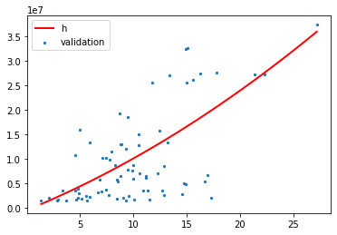

```python
get_h_plot(w)
```

## 加入類別變數的迴歸模型

## 如何擴增迴歸模型的可及範圍 $H$？

- 加入更多的特徵（features）
  - 高次項（polynomials）
  - **其他變數**
  - 其他衍生變數...etc.

## 籃球員的位置（Position）

```python
import pandas as pd
from sklearn.model_selection import train_test_split

nba_players = pd.read_csv("https://kaggle-getting-started.s3-ap-northeast-1.amazonaws.com/regression/nba_players.csv")
nba_players["pos"].unique()
```

```
array(['G', 'F', 'F-C', 'C', 'F-G', 'C-F', 'G-F'], dtype=object)
```

## 將位置簡化，Swingmen 或 Tweener 改以第一位置登錄

```python
pos_recategorize = {
    'G': 'G',
    'F': 'F',
    'F-C': 'F',
    'C': 'C',
    'F-G': 'F',
    'C-F': 'C',
    'G-F': 'G'
}
nba_players["pos_recategorized"] = nba_players["pos"].map(pos_recategorize)
print(nba_players["pos_recategorized"].unique())
print(nba_players["pos_recategorized"].value_counts())
```

```
['G' 'F' 'C']
G    99
F    95
C    35
Name: pos_recategorized, dtype: int64
```

## 將後衛、前鋒與中鋒用不同顏色在散佈圖標記

使用 `seaborn` 加速視覺化 https://seaborn.pydata.org/generated/seaborn.scatterplot.html

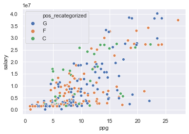

```python
get_scatter_plot()
```

## 看起來後衛（G）與前鋒（F）的 $h$ 相似，但中鋒（C）比較自成一格

## 我們能否依據 `pos_recategorized` 變數將 $h$ 調整為

$$\text{if pos_recategorized=='G':}\quad h^{(G)}(x) = w_0^{(G)} + w_1^{(G)} x_1\\ \text{if pos_recategorized=='F':}\quad h^{(F)}(x) = w_0^{(F)} + w_1^{(F)} x_1\\ \text{if pos_recategorized=='C':}\quad h^{(C)}(x) = w_0^{(C)} + w_1^{(C)} x_1\\ $$

## 將三個 `if` 條件所對應的 $h(x)$ 利用一個 $\delta$ 係數結合

$$h(x) = w_0^{(G)}\delta^{(G)} + w_1^{(G)}\delta^{(G)} x_1 + \\ w_0^{(F)}\delta^{(F)} + w_1^{(F)}\delta^{(F)} x_1 + \\ w_0^{(C)}\delta^{(C)} + w_1^{(C)}\delta^{(C)} x_1 $$

## $\delta$ 係數在不同鋒衛位置時

$$\delta^{(G)} = 1 \quad \text{if pos_recategorized=='G', otherwise} \quad \delta^{(G)} = 0\\ \delta^{(F)} = 1 \quad \text{if pos_recategorized=='F', otherwise} \quad \delta^{(F)} = 0 \\ \delta^{(C)} = 1 \quad \text{if pos_recategorized=='C', otherwise} \quad \delta^{(C)} = 0 $$

## `pos_recategorized=='G'`

$$h(x) = w_0^{(G)} + w_1^{(G)}x_1 $$

## `pos_recategorized=='F'`

$$h(x) = w_0^{(F)} + w_1^{(F)}x_1 $$

## `pos_recategorized=='C'`

$$h(x) = w_0^{(C)} + w_1^{(C)}x_1 $$

## 創建 $\delta$

```python
import numpy as np

recategorized_pos = nba_players["pos_recategorized"].unique()
char_to_int = {v: i for i, v in enumerate(recategorized_pos)}
print(char_to_int)
integers_encoded = [char_to_int[pos] for pos in nba_players["pos_recategorized"].values]
deltas = []
for v in integers_encoded:
    encoded_result = [0 for _ in range(len(char_to_int))]
    encoded_result[v] = 1
    deltas.append(encoded_result)
print(deltas[:20])
print(nba_players["pos_recategorized"].values[:20])
```

```
{'G': 0, 'F': 1, 'C': 2}
[[1, 0, 0], [1, 0, 0], [1, 0, 0], [1, 0, 0], [1, 0, 0], [0, 1, 0], [0, 1, 0], [1, 0, 0], [0, 1, 0], [0, 1, 0], [1, 0, 0], [0, 1, 0], [1, 0, 0], [0, 1, 0], [1, 0, 0], [1, 0, 0], [0, 0, 1], [0, 1, 0], [0, 0, 1], [0, 1, 0]]
['G' 'G' 'G' 'G' 'G' 'F' 'F' 'G' 'F' 'F' 'G' 'F' 'G' 'F' 'G' 'G' 'C' 'F'
 'C' 'F']
```

## 在資料框中新增 `delta_G`、`delta_F` 與 `delta_C` 三個變數

```python
import numpy as np

deltas_arr = np.array(deltas)
nba_players["delta_G"] = deltas_arr[:, 0]
nba_players["delta_F"] = deltas_arr[:, 1]
nba_players["delta_C"] = deltas_arr[:, 2]
```

```python
nba_players[["personId", "personName", "salary", "ppg", "pos_recategorized", "delta_G", "delta_F", "delta_C"]].head(20)
```

|  | personId | personName | salary | ppg | pos_recategorized | delta_G | delta_F | delta_C |
| --- | --- | --- | --- | --- | --- | --- | --- | --- |
| 0 | 201939 | Stephen Curry | 40231758 | 23.5 | G | 1 | 0 | 0 |
| 1 | 101108 | Chris Paul | 38506482 | 18.5 | G | 1 | 0 | 0 |
| 2 | 202322 | John Wall | 38199000 | 19.0 | G | 1 | 0 | 0 |
| 3 | 201935 | James Harden | 38199000 | 24.3 | G | 1 | 0 | 0 |
| 4 | 201566 | Russell Westbrook | 38150000 | 23.0 | G | 1 | 0 | 0 |
| 5 | 2544 | LeBron James | 37436858 | 27.2 | F | 0 | 1 | 0 |
| 6 | 201933 | Blake Griffin | 34234964 | 21.9 | F | 0 | 1 | 0 |
| 7 | 200768 | Kyle Lowry | 33296296 | 14.4 | G | 1 | 0 | 0 |
| 8 | 202331 | Paul George | 33005556 | 19.8 | F | 0 | 1 | 0 |
| 9 | 202330 | Gordon Hayward | 32700690 | 15.1 | F | 0 | 1 | 0 |
| 10 | 201144 | Mike Conley | 32511623 | 14.9 | G | 1 | 0 | 0 |
| 11 | 200794 | Paul Millsap | 30000000 | 14.1 | F | 0 | 1 | 0 |
| 12 | 203081 | Damian Lillard | 29802321 | 23.5 | G | 1 | 0 | 0 |
| 13 | 201567 | Kevin Love | 28942830 | 18.3 | F | 0 | 1 | 0 |
| 14 | 201942 | DeMar DeRozan | 27739975 | 19.9 | G | 1 | 0 | 0 |
| 15 | 203468 | CJ McCollum | 27556959 | 17.8 | G | 1 | 0 | 0 |
| 16 | 203999 | Nikola Jokic | 27504630 | 16.3 | C | 0 | 0 | 1 |
| 17 | 203952 | Andrew Wiggins | 27504630 | 19.4 | F | 0 | 1 | 0 |
| 18 | 1626157 | Karl-Anthony Towns | 27285000 | 22.3 | C | 0 | 0 | 1 |
| 19 | 1626164 | Devin Booker | 27285000 | 21.4 | F | 0 | 1 | 0 |

## 使用 `sklearn.preprocessing.OneHotEncoder` 創建 $\delta$

https://scikit-learn.org/stable/modules/generated/sklearn.preprocessing.OneHotEncoder.html

```python
pos_recategorize = {
    'G': 'G',
    'F': 'F',
    'F-C': 'F',
    'C': 'C',
    'F-G': 'F',
    'C-F': 'C',
    'G-F': 'G'
}
nba_players = pd.read_csv("https://kaggle-getting-started.s3-ap-northeast-1.amazonaws.com/regression/nba_players.csv")
nba_players["pos_recategorized"] = nba_players["pos"].map(pos_recategorize)
nba_players["pos_recategorized"].value_counts()
```

```
G    99
F    95
C    35
Name: pos_recategorized, dtype: int64
```

```python
nba_players[["personId", "personName", "salary", "ppg", "pos_recategorized", "delta_G", "delta_F", "delta_C"]].head(20)
```

[output not shown]

## 使用 `pd.get_dummies` 創建 $\delta$

https://pandas.pydata.org/pandas-docs/stable/reference/api/pandas.get_dummies.html

```python
pos_recatogorize = {
    'G': 'G',
    'F': 'F',
    'F-C': 'F',
    'C': 'C',
    'F-G': 'F',
    'C-F': 'C',
    'G-F': 'G'
}
nba_players = pd.read_csv("https://kaggle-getting-started.s3-ap-northeast-1.amazonaws.com/regression/nba_players.csv")
nba_players["pos_recategorized"] = nba_players["pos"].map(pos_recatogorize)
nba_players["pos_recategorized"].value_counts()
```

```
G    99
F    95
C    35
Name: pos_recategorized, dtype: int64
```

```python
nba_players[["personId", "personName", "salary", "ppg", "pos_recategorized", "delta_G", "delta_F", "delta_C"]].head(20)
```

[output not shown]

## 加入 $\delta$ 的迴歸模型

```python
pos_recatogorize = {
    'G': 'G',
    'F': 'F',
    'F-C': 'F',
    'C': 'C',
    'F-G': 'F',
    'C-F': 'C',
    'G-F': 'G'
}
nba_players = pd.read_csv("https://kaggle-getting-started.s3-ap-northeast-1.amazonaws.com/regression/nba_players.csv")
nba_players["pos_recatogorized"] = nba_players["pos"].map(pos_recatogorize)
recatogorized_pos = nba_players["pos_recatogorized"].values.reshape(-1, 1)
```

## 加入 $\delta$

```python
enc = OneHotEncoder(sparse=False, categories=[['G', 'F', 'C']], dtype=int)
deltas_arr = enc.fit_transform(recatogorized_pos)
nba_players["delta_G"] = deltas_arr[:, 0]
nba_players["delta_F"] = deltas_arr[:, 1]
nba_players["delta_C"] = deltas_arr[:, 2]
nba_players["delta_G_ppg"] = nba_players["delta_G"] * nba_players["ppg"]
nba_players["delta_F_ppg"] = nba_players["delta_F"] * nba_players["ppg"]
nba_players["delta_C_ppg"] = nba_players["delta_C"] * nba_players["ppg"]
X = nba_players[["delta_G", "delta_G_ppg", "delta_F", "delta_F_ppg", "delta_C", "delta_C_ppg"]].values
y = nba_players["salary"].values.reshape(-1, 1)
X_train, X_validation, y_train, y_validation = train_test_split(X, y, test_size=0.33, random_state=42)
```

## 使用 normal equations 解 $w$

```python
import numpy as np

w = get_w_ne(X_train, y_train)
y_pred = X_validation.dot(w)
mse = ((y_validation - y_pred)**2).sum() / y_pred.size
print(w)
print(mse)
```

```
[[-4004257.26991255]
 [ 1356560.45318115]
 [-2469225.37725407]
 [ 1282063.58072368]
 [ 1750448.19872396]
 [ 1204410.50906465]]
51875787073811.27
```

## 使用 `sklearn.linear_model.LinearRegression` 解 $w$

```python
from sklearn.linear_model import LinearRegression
from sklearn.metrics import mean_squared_error

lr = LinearRegression(fit_intercept=False)
lr.fit(X_train, y_train)
w = lr.coef_.reshape(-1, 1)
y_pred = lr.predict(X_validation)
mse = mean_squared_error(y_validation, y_pred)
```

```python
print(w)
print(mse)
```

```
[[-4004257.26991253]
 [ 1356560.45318115]
 [-2469225.37725405]
 [ 1282063.58072368]
 [ 1750448.19872395]
 [ 1204410.50906465]]
51875787073811.24
```

## 將 $h$ 在訓練資料上描繪出來

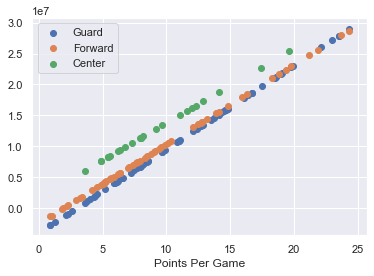

```python
column_indices = [0, 2, 4]
positions = ["Guard", "Forward", "Center"]
fig = plt.figure()
ax = plt.axes()
for i, position in zip(column_indices, positions):
    X_pred = X_train[X_train[:, i] == 1]
    y_pred = X_pred.dot(w)
    ax.scatter(X_pred[:, i+1], y_pred, label=position)
ax.legend(loc="upper left")
ax.set_xlabel("Points Per Game")
plt.show()
```

## 誤差的來源

## 機器學習：於可及範圍的 $H$ 中挑選一個與 $f$ 最相似的 $h_i$

但是 $h_i$ 與 $f$ 終究是不同的函數，而我們關心的是 $\hat{y}^{(test)}$ 與 $y^{(test)}$ 間的差異，差異小的 $h_i$ 稱為 Generalization（泛化）的能力好

## $h_i$ 的誤差可能源於 training error 與 test error

- training error 常被簡稱為 error
- test error 亦可被稱為 generalization error，被簡稱為 variance

## 擴增迴歸模型的可及範圍 $H$ 常伴隨 error 降低，variance 提高

```python
import pandas as pd
from sklearn.model_selection import train_test_split
from sklearn.preprocessing import PolynomialFeatures
from sklearn.linear_model import LinearRegression
from sklearn.metrics import mean_squared_error

nba_players = pd.read_csv("https://kaggle-getting-started.s3-ap-northeast-1.amazonaws.com/regression/nba_players.csv")
X = nba_players["ppg"].values.reshape(-1, 1)
```

```python
degrees = range(1, 11)
training_errors = []
test_errors = []
for deg in degrees:
    poly = PolynomialFeatures(degree = deg)
    X_poly = poly.fit_transform(X)
    y = nba_players["salary"].values
    X_train, X_validation, y_train, y_validation = train_test_split(X_poly, y, test_size=0.33, random_state=42)
    lr = LinearRegression()
    lr.fit(X_train, y_train)
    y_pred = lr.predict(X_train)
    training_err = mean_squared_error(y_train, y_pred)
    training_errors.append(training_err)
    y_pred = lr.predict(X_validation)
    test_err = mean_squared_error(y_validation, y_pred)
    test_errors.append(test_err)
```

```python
error_table = pd.DataFrame()
error_table["degree"] = degrees
error_table["training_error"] = training_errors
error_table["test_error"] = test_errors
error_table
```

|  | degree | training_error | test_error |
| --- | --- | --- | --- |
| 0 | 1 | 4.864718e+13 | 5.193857e+13 |
| 1 | 2 | 4.826583e+13 | 5.041154e+13 |
| 2 | 3 | 4.825389e+13 | 5.033960e+13 |
| 3 | 4 | 4.768415e+13 | 5.348273e+13 |
| 4 | 5 | 4.767123e+13 | 5.481827e+13 |
| 5 | 6 | 4.756032e+13 | 5.264442e+13 |
| 6 | 7 | 4.748795e+13 | 6.085192e+13 |
| 7 | 8 | 4.673157e+13 | 7.922933e+14 |
| 8 | 9 | 4.653261e+13 | 5.709749e+13 |
| 9 | 10 | 4.419225e+13 | 2.839142e+16 |

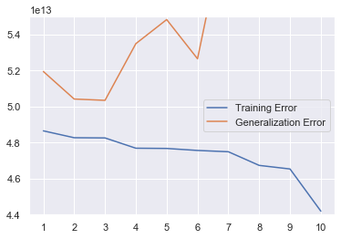

```python
import matplotlib.pyplot as plt

plt.plot(error_table["degree"], error_table["training_error"], label="Training Error")
plt.plot(error_table["degree"], error_table["test_error"], label="Generalization Error")
plt.legend(loc="center right")
plt.xticks(degrees, degrees)
plt.ylim(4.4e13, 5.5e13)
plt.show()
```

## 用兩個面向評斷 $h_i$ 是不是在 $H$ 中的一個好選擇（The capacity of $h_i$）

- Training error 是否夠小
- Training error 與 Generalization error 之間的差異是否夠小

## 這兩個面向分別對應到機器學習的挑戰

- Underfitting（配適不足）：Training Error 與 Generalization error 均大
- Overfitting（過度配適）：Training Error 小，但是 Generalization error 大

## Underfitting（配適不足）

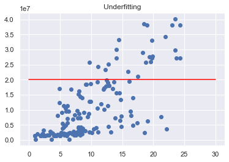

```python
get_underfitting_plot()
```

## Overfitting（過度配適）

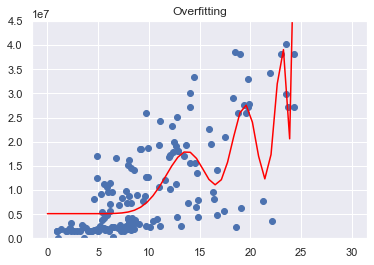

```python
get_overfitting_plot()
```

## 正規化（Regularization）

如何讓 $h$ 在加入更多高次項、特徵時盡可能保持平滑的方法

$$MSE_{train} = \frac{1}{m}\sum_i(w^Tx^{train} - y^{(train)})_i^2 + \lambda \sum_{i} w_i^2 \\ MSE_{train} = (X^{(train)}w - y^{(train)})^T(X^{(train)}w - y^{(train)}) + \lambda w^Tw $$

## 具備正規化的 Normal equations

$$ \bigtriangledown_w MSE_{train} = 0 \\ \bigtriangledown_w \big((X^{(train)}w - y^{(train)})^T(X^{(train)}w - y^{(train)}) + \lambda w^Tw\big) = 0 \\ \frac{\partial}{\partial w} \big(w^TX^{(train)T}X^{(train)}w - 2w^TX^{(train)T}y^{(train)} + y^{(train)T}y^{(train)} + \lambda w^Tw\big) = 0 \\ 2X^{(train)T}X^{(train)}w - 2X^{(train)T}y^{(train)} + 2\lambda w = 0 \\ X^{(train)T}X^{(train)}w + \lambda w = X^{(train)T}y^{(train)} \\ (X^{(train)T}X^{(train)} + \lambda I)w = X^{(train)T}y^{(train)} \\ w = (X^{(train)T}X^{(train)} + \lambda I)^{-1} X^{(train)T}y^{(train)} $$

## 觀察在 $\lambda = 0$ 時候的正規化效果

## 給定 $X_{train}$、$y_{train}$ 與 $\lambda = 0$ 利用 normal equations with regularization 求 $w$

```python
import pandas as pd
from sklearn.model_selection import train_test_split
from sklearn.preprocessing import PolynomialFeatures

nba_players = pd.read_csv("https://kaggle-getting-started.s3-ap-northeast-1.amazonaws.com/regression/nba_players.csv")
X = nba_players["ppg"].values.reshape(-1, 1)
poly = PolynomialFeatures(3)
X_poly = poly.fit_transform(X)
y = nba_players["salary"].values.reshape(-1, 1)
X_train, X_validation, y_train, y_validation = train_test_split(X_poly, y, test_size=0.33, random_state=42)
```

```python
import numpy as np

def get_w_ne_reg(X_train, y_train, lambda_coef):
    n = X_train.shape[1]
    I = np.eye(n)
    left_mat = X_train.T.dot(X_train) + lambda_coef*I
    right_mat = X_train.T.dot(y_train)
    w = np.linalg.inv(left_mat).dot(right_mat)
    return w
w = get_w_ne_reg(X_train, y_train, lambda_coef=0)
```

```python
print(w)
```

```
[[-9.77516476e+05]
 [ 1.05759814e+06]
 [ 9.15355806e+01]
 [ 4.54185541e+02]]
```

## 給定 $X_{train}$、$y_{train}$ 利用 `sklearn.linear_model.LinearRegression` 求 $w$

```python
nba_players = pd.read_csv("https://kaggle-getting-started.s3-ap-northeast-1.amazonaws.com/regression/nba_players.csv")
X = nba_players["ppg"].values.reshape(-1, 1)
poly = PolynomialFeatures(3)
X_poly = poly.fit_transform(X)
y = nba_players["salary"].values.reshape(-1, 1)
X_train, X_validation, y_train, y_validation = train_test_split(X_poly, y, test_size=0.33, random_state=42)
```

```python
from sklearn.linear_model import LinearRegression

lr = LinearRegression()
lr.fit(X_train, y_train)
w_0 = lr.intercept_
w_i = lr.coef_[0][1:]
w = np.concatenate([w_0, w_i]).reshape(-1, 1)
print(w)
```

```
[[-9.77516476e+05]
 [ 1.05759814e+06]
 [ 9.15355806e+01]
 [ 4.54185541e+02]]
```

## 比對後發現即便使用 normal equations with regularization 求 $w$，在 $\lambda = 0$ 的情況下跟 `sklearn.linear_model.LinearRegression` 得到的結果相同，意即沒有正規化

## 觀察在 $\lambda = 1000$ 時候的正規化效果

## 給定 $X_{train}$、$y_{train}$ 與 $\lambda = 1000$ 利用 normal equations with regularization 求 $w$

```python
import pandas as pd
from sklearn.model_selection import train_test_split
from sklearn.preprocessing import PolynomialFeatures

nba_players = pd.read_csv("https://kaggle-getting-started.s3-ap-northeast-1.amazonaws.com/regression/nba_players.csv")
X = nba_players["ppg"].values.reshape(-1, 1)
poly = PolynomialFeatures(3)
X_poly = poly.fit_transform(X)
y = nba_players["salary"].values.reshape(-1, 1)
X_train, X_validation, y_train, y_validation = train_test_split(X_poly, y, test_size=0.33, random_state=42)
```

```python
w = get_w_ne_reg(X_train, y_train, lambda_coef=1000)
print(w)
```

```
[[ 56742.49041756]
 [218855.2007004 ]
 [ 96548.39842007]
 [ -2304.84362384]]
```

## 給定 $X_{train}$、$y_{train}$ 與 $\lambda = 1000$ 利用 `sklearn.linear_model.Ridge` 求 $w$

```python
nba_players = pd.read_csv("https://kaggle-getting-started.s3-ap-northeast-1.amazonaws.com/regression/nba_players.csv")
X = nba_players["ppg"].values.reshape(-1, 1)
poly = PolynomialFeatures(3)
X_poly = poly.fit_transform(X)
y = nba_players["salary"].values.reshape(-1, 1)
X_train, X_validation, y_train, y_validation = train_test_split(X_poly, y, test_size=0.33, random_state=42)
```

```python
from sklearn.linear_model import Ridge

ridge = Ridge(alpha=1000, fit_intercept=False)
ridge.fit(X_train, y_train)
w_i = ridge.coef_
w = w_i.reshape(-1, 1)
print(w)
```

```
[[ 56742.49041714]
 [218855.20070045]
 [ 96548.39842007]
 [ -2304.84362384]]
```

## 使用高次項（degree = 10）時加入正規化

```python
nba_players = pd.read_csv("https://kaggle-getting-started.s3-ap-northeast-1.amazonaws.com/regression/nba_players.csv")
X = nba_players[["ppg"]].values
poly = PolynomialFeatures(10)
X_poly = poly.fit_transform(X)
y = nba_players["salary"].values
X_train, X_validation, y_train, y_validation = train_test_split(X_poly, y, test_size=0.33, random_state=42)
```

```python
import matplotlib.pyplot as plt
import numpy as np

def get_w_ne_reg(X_train, y_train, lambda_coef):
    n = X_train.shape[1]
    I = np.eye(n)
    left_mat = X_train.T.dot(X_train) + lambda_coef*I
    right_mat = X_train.T.dot(y_train)
    w = np.linalg.inv(left_mat).dot(right_mat)
    return w

def get_regularized_plot(X_train, y_train, lambda_coef):
    X_pred = np.linspace(0, 30).reshape(-1, 1)
    X_pred_poly = poly.fit_transform(X_pred)
    w = get_w_ne_reg(X_train, y_train, lambda_coef)
    y_pred = X_pred_poly.dot(w)
    plt.scatter(X_train[:, 1], y_train)
    plt.plot(X_pred_poly[:, 1], y_pred, c="red")
    plt.title("$\lambda: {:.0e}$".format(lambda_coef))
    plt.ylim(0, 5e7)
    plt.show()
```

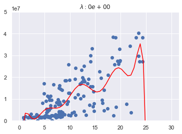

```python
get_regularized_plot(X_train, y_train, 0)
```

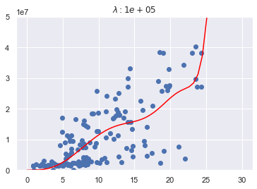

```python
get_regularized_plot(X_train, y_train, 1e5)
```

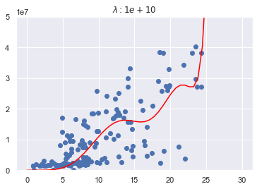

```python
get_regularized_plot(X_train, y_train, 1e10)
```

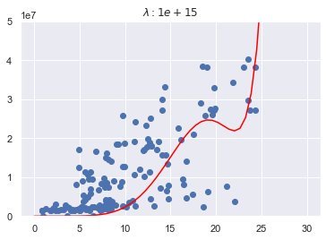

```python
get_regularized_plot(X_train, y_train, 1e15)
```

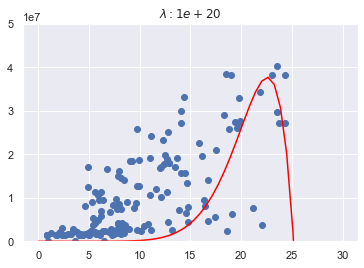

```python
get_regularized_plot(X_train, y_train, 1e20)
```

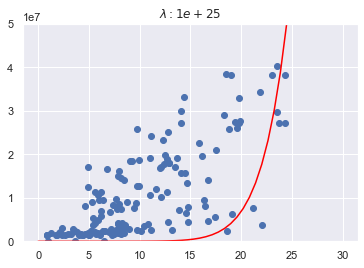

```python
get_regularized_plot(X_train, y_train, 1e25)
```

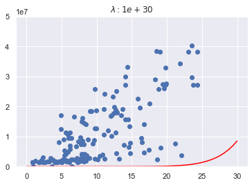

```python
get_regularized_plot(X_train, y_train, 1e30)
```

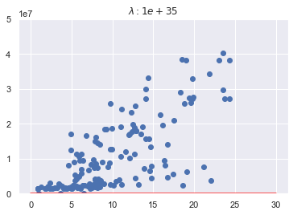

```python
get_regularized_plot(X_train, y_train, 1e35)
```

## 紀錄不同 $\lambda$ 對應的 training error 與 test error

```python
import numpy as np
import pandas as pd
from sklearn.model_selection import train_test_split
from sklearn.preprocessing import PolynomialFeatures
from sklearn.linear_model import Ridge

nba_players = pd.read_csv("https://kaggle-getting-started.s3-ap-northeast-1.amazonaws.com/regression/nba_players.csv")
X = nba_players[["ppg"]].values
poly = PolynomialFeatures(10)
X_poly = poly.fit_transform(X)
y = nba_players["salary"].values
X_train, X_validation, y_train, y_validation = train_test_split(X_poly, y, test_size=0.33, random_state=42)
```

```python
from sklearn.metrics import mean_squared_error

training_errs = []
test_errs = []
lambda_coefs = [0, 1e3, 1e6, 1e9, 1e12, 1e15, 1e18, 1e21, 1e24, 1e27]
for lambda_coef in lambda_coefs:
    w = get_w_ne_reg(X_train, y_train, lambda_coef)
    y_pred = X_train.dot(w)
    training_err = mean_squared_error(y_train, y_pred)
    training_errs.append(training_err)
    y_pred = X_validation.dot(w)
    test_err = mean_squared_error(y_validation, y_pred)
    test_errs.append(test_err)
```

```python
error_table = pd.DataFrame()
error_table["lambda"] = lambda_coefs
error_table["training_error"] = training_errs
error_table["test_error"] = test_errs
error_table
```

|  | lambda | training_error | test_error |
| --- | --- | --- | --- |
| 0 | 0.000000e+00 | 4.418922e+13 | 2.844419e+16 |
| 1 | 1.000000e+03 | 4.687651e+13 | 1.479087e+14 |
| 2 | 1.000000e+06 | 4.812994e+13 | 1.302742e+14 |
| 3 | 1.000000e+09 | 5.010228e+13 | 3.031131e+15 |
| 4 | 1.000000e+12 | 6.256581e+13 | 1.105003e+15 |
| 5 | 1.000000e+15 | 7.631259e+13 | 5.457173e+14 |
| 6 | 1.000000e+18 | 8.781500e+13 | 7.819243e+14 |
| 7 | 1.000000e+21 | 1.148595e+14 | 6.441674e+14 |
| 8 | 1.000000e+24 | 1.471107e+14 | 2.140092e+14 |
| 9 | 1.000000e+27 | 1.536502e+14 | 2.679916e+14 |